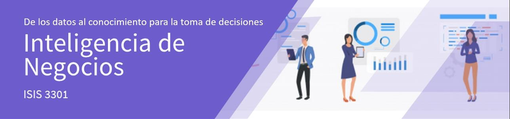

# Proyecto 1 - Análitica de textos

**Objetivo:** Aplicar la metodología de analítica de textos para la construcción de soluciones de analítica alineadas con los objetivos del negocio en un contexto de aplicación.

**Problema:** Determinar la elegibilidad de un paciente para ensayos clínicos de cáncer a partir de texto descriptivo.

# 1. Instalación e importe de librerías

En las siguientes líneas de código se importan las librerías y herramientas necesarias para desarrollar el proyecto 1 contemplando la etapa de exploración y perfilamiento de datos, la descripción de los datos, la limpieza y preparación de datos, la normalización y tokenización de las palabras, la transformaciones tf-idf y la construcción de modelos de clasificación (Decision Tree, Random Forest y Logistic Reggresion).

```python
# Librería para manejar las contracciones que se presentan en el inglés
!pip install contractions
```

```
     |████████████████████████████████| 106 kB 4.3 MB/s
     |████████████████████████████████| 284 kB 29.7 MB/s
```

```python
# Librería para manejar las flexiones gramaticales en el idioma inglés
!pip install inflect
!pip install pandas-profiling==3.1.0
```

[output not shown]

```python
# Importe de librerias
seed = 161
import pandas as pd
import numpy as np
import sys
from pandas_profiling import ProfileReport
import re, string, unicodedata

# librería Natural Language Toolkit, usada para trabajar con textos
import nltk
# Punkt permite separar un texto en frases.
nltk.download('punkt')
nltk.download('stopwords')
# Descarga de paquete WordNetLemmatizer, este es usado para encontrar el lema de cada palabra
nltk.download('wordnet')

# Preprocesamiento de texto.
import contractions
import inflect
from nltk import word_tokenize, sent_tokenize
from nltk.corpus import stopwords
from nltk.stem import LancasterStemmer, WordNetLemmatizer

# Pipelines y preprocesamiento de datos.
from sklearn.feature_extraction.text import TfidfVectorizer
from sklearn.pipeline import Pipeline, FeatureUnion
from imblearn.pipeline import Pipeline
from sklearn.compose import ColumnTransformer

# Modelos.
from sklearn.ensemble import RandomForestClassifier
from sklearn.naive_bayes import MultinomialNB
from sklearn.neighbors import KNeighborsClassifier
from sklearn.svm import SVC
from sklearn.linear_model import LogisticRegression
from sklearn.tree import DecisionTreeClassifier

# Para búsqueda de hiperparámetros
from sklearn.model_selection import train_test_split,GridSearchCV
# Para la validación cruzada
from sklearn.model_selection import KFold

# Métricas para evaluar el modelo
from sklearn.metrics import precision_score, recall_score, f1_score, accuracy_score
from sklearn.metrics import plot_confusion_matrix
from sklearn.metrics import classification_report, confusion_matrix, plot_precision_recall_curve, plot_confusion_matrix
from sklearn.metrics import confusion_matrix, ConfusionMatrixDisplay
from sklearn.svm import SVC

# Gráficos
import matplotlib.pyplot as plt
from sklearn import tree
from sklearn.tree import export_graphviz

# Importar/Exportar modelos
from joblib import dump, load
```

# 2. Exploración de los datos

En está etapa se realiza el proceso correspondiente al primer acercamiento de exploraciónde a los datos proporcionados con el fin de comprender que datos tenemos y sus propiedades.

```python
# Uso de la libreria pandas para la lectura de archivos
data=pd.read_csv('/content/clinical_trials_on_cancer_data_clasificacion.csv', sep=',', encoding = 'utf-8')

# Asignación a una nueva variable de los datos leidos
data_t=data
```

```python
# Visualizar una muestra de 5 registro del conjunto de datos
data_t.sample(5)
```

|  | label | study_and_condition |
| --- | --- | --- |
| 3320 | __label__1 | study interventions are Pentamidine . non smal... |
| 1484 | __label__1 | study interventions are Doxorubicin . solid tu... |
| 8169 | __label__1 | study interventions are Antibodies, Monoclonal... |
| 10904 | __label__0 | study interventions are Vaccines . sarcomas di... |
| 10534 | __label__1 | study interventions are Therapeutic Convention... |

```python
# Tipos de las variables del conjunto de datos porporcionados
data_t.dtypes
```

```
label                  object
study_and_condition    object
dtype: object
```

Se evidencia que todas las variables del conjunto de datos son de tipo "object".

```python
# Contar los valores nulos en cada una de las columnas
data_t.isnull().sum().sort_values()
```

```
label                  0
study_and_condition    0
dtype: int64
```

Se observa que no hay valores nulos en el conjunto de datos proporcionados.

```python
# Crear copia del conjunto de datos en la variable df
df = data_t
```

```python
# Dimensiones de los datos (filas, columnas)
df.shape
```

```
(12000, 2)
```

Se tiene en total 12000 registros y 2 variables (label, study_and_condition).

# 3. Perfilamiento y entendimiento de los datos

En está etapa se realiza el proceso correspondiente al perfilaminto y entendimiento de los datos proporcionados con el fin de resolver el problema planteado por el negocio.

En primera instancia, obtendremos estadísticas descriptivas pertinentes para comprender los datos. Posteriormente ingresaremos el conjunto de datos a Pandas Profiling para obtener un reporte adecuado de correlación e interacción entre variables del conjunto de datos.

En primer lugar vamos a ver un conteo, moda, máximo y mínimo de los datos.

```python
# Crear las variables 'conteo', 'moda', 'max' y 'min' con sus respectivas operaciones para obtener estadísitcas descriptivas
df['Conteo'] = [len(x) for x in df['study_and_condition']]
df['Moda'] = [max(set(x.split(' ')), key = x.split(' ').count) for x in df['study_and_condition']]
df['Max'] = [[max([len(x) for x in i.split(' ')])][0] for i in df['study_and_condition']]
df['Min'] = [[min([len(x) for x in i.split(' ')])][0] for i in df['study_and_condition']]
```

```python
# Visualizar una muestra de 5 registro del conjunto de datos
df.sample(5)
```

|  | label | study_and_condition | Conteo | Moda | Max | Min |
| --- | --- | --- | --- | --- | --- | --- |
| 8369 | __label__0 | study interventions are Cyclosporins . stage g... | 139 | diagnosis | 22 | 1 |
| 4379 | __label__1 | study interventions are Immunoglobulins . recu... | 427 | or | 17 | 1 |
| 11823 | __label__0 | study interventions are Fludarabine phosphate ... | 325 | and | 16 | 1 |
| 5843 | __label__0 | study interventions are Staurosporine . hertwo... | 114 | diagnosis | 13 | 1 |
| 7341 | __label__1 | study interventions are Fludarabine . recurren... | 126 | diagnosis | 13 | 1 |

```python
# Creación y visualización del profile pandas en base al conjunto de datos proporcionados
profile = ProfileReport(df)
profile
```

[interactive chart not shown]

```python
# Guardar el pandas profiling generado con el conjunto de datos proporcionados
profile.to_file("Analysis.html")
profile.to_file("Analysis.json")
```

Del profile reporting se puede observar que en una primera instancia, nuestra variable objetivo se encuentra balanceada dado que hay 6000 registros para el label 0 y otros 6000 registros para el label 1.

En segundo lugar vemos que no hay registros vacíos o nulos.

En tercer lugar se ve que hay un 0.1% de registros duplicadas, es decir, 12 registros duplicados en el conjunto de datos. Dado que la información repetida no aporta nada al modelo, se eliminan estos registros.

```python
# Eliminar los 12 registros duplicados del conjunto de datos
df = df.drop_duplicates()
```

```python
# Dimensiones de los datos (filas, columnas)
df.shape
```

```
(11988, 6)
```

# 3. Preparación de los datos

En esta etapa se realiza el pre-procesamiento del conjunto de datos, por lo cual se sigue por las siguientes tres etapas contempladas en la analítica de textos:

- Limpieza de los datos.
- Normalización.
- Tokenización.

## 3.1 Limpieza de los datos

Para dejar el archivo en texto plano, se remueven los caracteres que no son ASCII y se convierte todo a minúsculas. Asimismo, se borran los signos de puntuación conjuntamente con el reemplazo de los números por su representación textual. Por último, se remueven las palabras terminación.

```python
# Función que remueve los caracteres que non-ASCII de la lista de palabras
def remove_non_ascii(words):
    """Remove non-ASCII characters from list of tokenized words"""
    new_words = []
    for word in words:
        new_word = unicodedata.normalize('NFKD', word).encode('ascii', 'ignore').decode('utf-8', 'ignore')
        new_words.append(new_word)
    return new_words

# Función que convierte todas las palabras a minúsculas
def to_lowercase(words):
    """Convert all characters to lowercase from list of tokenized words"""
    new_words = []
    for word in words:
        new_word = word.lower()
        new_words.append(new_word)
    return new_words

# Función que remueve todos los signos de puntuación
def remove_punctuation(words):
    """Remove punctuation from list of tokenized words"""
    new_words = []
    for word in words:
        new_word = re.sub(r'[^\w\s]', '', word)
        if new_word != '':
            new_words.append(new_word)
    return new_words

# Función que reemplaza los numeros a representacion textual
def replace_numbers(words):
    """Replace all interger occurrences in list of tokenized words with textual representation"""
    p = inflect.engine()
    new_words = []
    for word in words:
        if word.isdigit():
            new_word = p.number_to_words(word)
            new_words.append(new_word)
        else:
            new_words.append(word)
    return new_words

# Funcion que remueve las palabras terminales del texto
def remove_stopwords(words):
    """Remove stop words from list of tokenized words"""
    new_words = []
    for word in words:
        if word not in stopwords.words('english'):
            new_words.append(word)
    return new_words

# Aplicar las funciones previemente definidas para la limpieza de los datos (textos)
def preprocessing(words):
    words = to_lowercase(words)
    words = replace_numbers(words)
    words = remove_punctuation(words)
    words = remove_non_ascii(words)
    words = remove_stopwords(words)

    return words
```

## 3.2 Tokenización

En esta sección, se realiza el proceso de tokenización de los textos del conjunto de datos con el fin de dividir los textos en palabras para su posterior análisis y procesamiento.

```python
# Aplicar la corrección de las contracciones en los textos de los registros del conjunto de datos
df['study_and_condition'] = df['study_and_condition'].apply(contractions.fix)
```

```python
# División del texto por "." para tener los sub textos study y condition como lo establecen en el diccionario de los datos
df['study'] = [x.split(' . ')[0] for x in df['study_and_condition']]
df['condition'] = [x.split(' . ')[1] for x in df['study_and_condition']]

# Visualizar una muestra de 5 registro del conjunto de datos
df.sample(5)
```

|  | label | study_and_condition | Conteo | Moda | Max | Min | study | condition |
| --- | --- | --- | --- | --- | --- | --- | --- | --- |
| 10936 | __label__1 | study interventions are Liposomal doxorubicin ... | 178 | study | 13 | 1 | study interventions are Liposomal doxorubicin | stage iiib uterine corpus cancer diagnosis and... |
| 11785 | __label__0 | study interventions are Antibodies, Monoclonal... | 258 | bilirubin | 13 | 1 | study interventions are Antibodies, Monoclonal | stage ivb laryngeal squamous cell carcinoma di... |
| 7510 | __label__1 | study interventions are laboratory biomarker a... | 116 | diagnosis | 13 | 1 | study interventions are laboratory biomarker a... | recurrent adult diffuse large cell lymphoma di... |
| 9642 | __label__0 | study interventions are Vidarabine . extranoda... | 142 | are | 13 | 1 | study interventions are Vidarabine | extranodal marginal zone cell lymphoma of muco... |
| 8278 | __label__0 | study interventions are Antibodies, Monoclonal... | 126 | are | 13 | 1 | study interventions are Antibodies, Monoclonal | lymphoma cell diagnosis and female patients wh... |

```python
# Crear las variables 'conteo_study', 'moda_study', 'max_study' y 'min_study' con sus respectivas operaciones para obtener estadísitcas descriptivas de la variable "study"
df['Conteo_study'] = [len(x) for x in df['study']]
df['Moda_study'] = [max(set(x.split(' ')), key = x.split(' ').count) for x in df['study']]
df['Max_study'] = [[max([len(x) for x in i.split(' ')])][0] for i in df['study']]
df['Min_study'] = [[min([len(x) for x in i.split(' ')])][0] for i in df['study']]

# Crear las variables 'conteo_study', 'moda_condition', 'max_condition' y 'min_condition' con sus respectivas operaciones para obtener estadísitcas descriptivas de la variable "condition"
df['Conteo_condition'] = [len(x) for x in df['condition']]
df['Moda_condition'] = [max(set(x.split(' ')), key = x.split(' ').count) for x in df['condition']]
df['Max_condition'] = [[max([len(x) for x in i.split(' ')])][0] for i in df['condition']]
df['Min_condition'] = [[min([len(x) for x in i.split(' ')])][0] for i in df['condition']]

# Eliminar las variables 'conteo', 'moda', 'max' y 'min' del conjunto de datos
df = df.drop(['Conteo'], axis=1)
df = df.drop(['Moda'], axis=1)
df = df.drop(['Max'], axis=1)
df = df.drop(['Min'], axis=1)

# Visualizar una muestra de 3 registro del conjunto de datos para ver los cambios aplicados
df.sample(3)
```

[output not shown]

|  | label | study_and_condition | study | condition | Conteo_study | Moda_study | Max_study | Min_study | Conteo_condition | Moda_condition | Max_condition | Min_condition |
| --- | --- | --- | --- | --- | --- | --- | --- | --- | --- | --- | --- | --- |
| 3834 | __label__0 | study interventions are Octreotide . neuroblas... | study interventions are Octreotide | neuroblastoma diagnosis and signed informed co... | 34 | study | 13 | 3 | 51 | diagnosis | 13 | 3 |
| 7888 | __label__0 | study interventions are Topotecan . central ne... | study interventions are Topotecan | central nervous system tumors diagnosis and pa... | 33 | study | 13 | 3 | 67 | patient | 15 | 3 |
| 4276 | __label__0 | study interventions are Belinostat . recurrent... | study interventions are Belinostat | recurrent grade one follicular lymphoma diagno... | 34 | study | 13 | 3 | 141 | or | 19 | 2 |

```python
# Aplicar la eliminación del ruido en las varibles "study" y "condition"
df['words_study'] = df['study'].apply(word_tokenize).apply(preprocessing)
df['words_condition'] = df['condition'].apply(word_tokenize).apply(preprocessing)

# Visualizar los registros de la cabecer del conjunto de datos para ver los cambios aplicados
df.head()
```

|  | label | study_and_condition | study | condition | Conteo_study | Moda_study | Max_study | Min_study | Conteo_condition | Moda_condition | Max_condition | Min_condition | words_study | words_condition |
| --- | --- | --- | --- | --- | --- | --- | --- | --- | --- | --- | --- | --- | --- | --- |
| 0 | __label__0 | study interventions are Saracatinib . recurren... | study interventions are Saracatinib | recurrent verrucous carcinoma of the larynx di... | 35 | study | 13 | 3 | 212 | of | 15 | 2 | [study, interventions, saracatinib] | [recurrent, verrucous, carcinoma, larynx, diag... |
| 1 | __label__1 | study interventions are Stem cell transplantat... | study interventions are Stem cell transplantation | hodgkin lymphoma diagnosis and history of cong... | 49 | Stem | 15 | 3 | 172 | the | 11 | 2 | [study, interventions, stem, cell, transplanta... | [hodgkin, lymphoma, diagnosis, history, congen... |
| 2 | __label__0 | study interventions are Lenograstim . recurren... | study interventions are Lenograstim | recurrent adult diffuse mixed cell lymphoma di... | 35 | study | 13 | 3 | 191 | diffuse | 12 | 2 | [study, interventions, lenograstim] | [recurrent, adult, diffuse, mixed, cell, lymph... |
| 3 | __label__0 | study interventions are Doxorubicin . stage ii... | study interventions are Doxorubicin | stage iii diffuse large cell lymphoma diagnosi... | 35 | study | 13 | 3 | 230 | stage | 9 | 2 | [study, interventions, doxorubicin] | [stage, iii, diffuse, large, cell, lymphoma, d... |
| 4 | __label__1 | study interventions are Poly I-C . prostate ca... | study interventions are Poly I-C | prostate cancer diagnosis and unresolved iraes... | 32 | I-C | 13 | 3 | 197 | and | 15 | 2 | [study, interventions, poly, ic] | [prostate, cancer, diagnosis, unresolved, irae... |

Se identifica que en todos los registros el texto que describe el estudio empieza con "Study interventions", por lo que se decide eliminar estas palabras de la variable 'words_study' en todos los registros del conjunto de datos.

```python
# Copiar el conjunto de datos en una nueva variable "df_c"
df_c = df.copy()

# Función que elimina las palabras "interventions" y "study" de todos los registros del conjunto de datos
def delete_words_study(row):
  if (str(row[1]) ==  'interventions'):
    row.remove('interventions')
  if (str(row[0]) ==  'study'):
    row.remove('study')
  elif (str(row[0]) ==  '"study'):
    row.remove('"study')
  return row

# Aplicar la función delete_words_study(x) a los registros del conjunto de datos
df_c['words_study'] = df_c['words_study'].apply(lambda x: delete_words_study(x))

# Visualizar una muestra de 5 registro del conjunto de datos para ver los cambios aplicados
df_c.sample(5)
```

|  | label | study_and_condition | study | condition | Conteo_study | Moda_study | Max_study | Min_study | Conteo_condition | Moda_condition | Max_condition | Min_condition | words_study | words_condition |
| --- | --- | --- | --- | --- | --- | --- | --- | --- | --- | --- | --- | --- | --- | --- |
| 7457 | __label__1 | study interventions are Cytarabine . splenic m... | study interventions are Cytarabine | splenic marginal zone lymphoma diagnosis and e... | 34 | study | 13 | 3 | 99 | diagnosis | 15 | 3 | [cytarabine] | [splenic, marginal, zone, lymphoma, diagnosis,... |
| 866 | __label__1 | study interventions are Bortezomib . carcinoma... | study interventions are Bortezomib | carcinoma squamous diagnosis and patients who ... | 34 | study | 13 | 3 | 261 | weeks | 12 | 2 | [bortezomib] | [carcinoma, squamous, diagnosis, patients, che... |
| 7108 | __label__0 | study interventions are Lapatinib . advanced c... | study interventions are Lapatinib | advanced cancers diagnosis and total bilirubin... | 33 | study | 13 | 3 | 119 | uln | 10 | 3 | [lapatinib] | [advanced, cancers, diagnosis, total, bilirubi... |
| 6460 | __label__1 | study interventions are Laboratory Biomarker A... | study interventions are Laboratory Biomarker A... | anaplastic large cell lymphoma alk positive di... | 53 | Biomarker | 13 | 3 | 443 | or | 12 | 2 | [laboratory, biomarker, analysis] | [anaplastic, large, cell, lymphoma, alk, posit... |
| 10584 | __label__0 | study interventions are Aspirin . the characte... | study interventions are Aspirin | the characteristics of the tumor | 31 | study | 13 | 3 | 32 | the | 15 | 2 | [aspirin] | [characteristics, tumor] |

## 3.3 Normalización

En esta sección, se realiza la normalización de los datos en la cual se elimina los prefijos y sufijos de las palabras y asimismo se ejecuta el proceso de lematización.

```python
# Funcion que elimina laspPalabras madre en la lista de palabras tokenizadas
def stem_words(words):
    """Stem words in list of tokenized words"""
    stemmer = LancasterStemmer()
    stems = []
    for word in words:
        stem = stemmer.stem(word)
        stems.append(stem)
    return stems

# Funcion que se encarga de realizar el proceso de lematización
def lemmatize_verbs(words):
    """Lemmatize verbs in list of tokenized words"""
    lemmatizer = WordNetLemmatizer()
    lemmas = []
    for word in words:
        lemma = lemmatizer.lemmatize(word, pos='v')
        lemmas.append(lemma)
    return lemmas

# Función que agrupa las funciones previamente definidas
def stem_and_lemmatize(words):
    stems = stem_words(words)
    lemmas = lemmatize_verbs(words)
    return stems + lemmas
```

```python
# Aplica lematización y eliminación de pefijos y sufijos de las palabras
df['words_study'] = df['words_study'].apply(stem_and_lemmatize)
df['words_condition'] = df['words_condition'].apply(stem_and_lemmatize)

# Guardar el conjunto de datos con los procesos anteriores aplicados (Limpieza de los datos, Tokenización y Normalización)
df.to_csv("muestreo_lemmatize.csv", sep=',', encoding='utf-8')
```

```python
# Visualizar una muestra de 5 registro del conjunto de datos para ver los cambios aplicados
df.sample(5)
```

|  | label | study_and_condition | study | condition | Conteo_study | Moda_study | Max_study | Min_study | Conteo_condition | Moda_condition | Max_condition | Min_condition | words_study | words_condition |
| --- | --- | --- | --- | --- | --- | --- | --- | --- | --- | --- | --- | --- | --- | --- |
| 6733 | __label__1 | study interventions are musculoskeletal compli... | study interventions are musculoskeletal compli... | myelodysplastic myeloproliferative neoplasm un... | 75 | musculoskeletal | 21 | 3 | 93 | neoplasm | 18 | 3 | [musculoskelet, comply, managementprev, muscul... | [myelodysplast, myeloprol, neoplasm, unclass, ... |
| 6793 | __label__1 | study interventions are Carmustine . recurrent... | study interventions are Carmustine | recurrent cell non hodgkin lymphoma diagnosis ... | 34 | study | 13 | 3 | 91 | cell | 10 | 2 | [carmustin, carmustine] | [recur, cel, non, hodgkin, lymphom, diagnos, p... |
| 2282 | __label__0 | study interventions are Antibodies, Monoclonal... | study interventions are Antibodies, Monoclonal | stage iv skin melanoma diagnosis and fertile p... | 46 | Monoclonal | 13 | 3 | 86 | diagnosis | 13 | 2 | [antibody, monoclon, antibodies, monoclonal] | [stag, iv, skin, melanom, diagnos, fertil, pat... |
| 5618 | __label__0 | study interventions are Paclitaxel . rhabdomyo... | study interventions are Paclitaxel | rhabdomyosarcoma diagnosis and myelosuppressiv... | 34 | study | 13 | 3 | 60 | diagnosis | 16 | 3 | [paclitaxel, paclitaxel] | [rhabdomyosarcom, diagnos, myelosuppress, chem... |
| 9427 | __label__1 | study interventions are Gene-Modified HIV-Prot... | study interventions are Gene-Modified HIV-Prot... | aids related hodgkin lymphoma diagnosis and ac... | 76 | HIV-Protected | 13 | 3 | 162 | or | 13 | 2 | [genemod, hivprotect, hematopoiet, stem, cel, ... | [aid, rel, hodgkin, lymphom, diagnos, act, inf... |

## 3.4 Procesar mensaje

Una vez realizado el proceso de limpieza, tokenización, normalización y haber obtenido las palabras que van a determinar nuestros modelos de clasificación. Se procede a procesar el mensaje original.

```python
# Procesar el texto original de las variables "words_study" y "words_condition"
df['processed_study'] = df['words_study'].apply(lambda x: ' '.join(map(str, x)))
df['processed_condition'] = df['words_condition'].apply(lambda x: ' '.join(map(str, x)))
df
```

|  | label | study_and_condition | study | condition | Conteo_study | Moda_study | Max_study | Min_study | Conteo_condition | Moda_condition | Max_condition | Min_condition | words_study | words_condition | processed_study | processed_condition |
| --- | --- | --- | --- | --- | --- | --- | --- | --- | --- | --- | --- | --- | --- | --- | --- | --- |
| 0 | __label__0 | study interventions are Saracatinib . recurren... | study interventions are Saracatinib | recurrent verrucous carcinoma of the larynx di... | 35 | study | 13 | 3 | 212 | of | 15 | 2 | [saracatinib, saracatinib] | [recur, verruc, carcinom, larynx, diagnos, pat... | saracatinib saracatinib | recur verruc carcinom larynx diagnos paty must... |
| 1 | __label__1 | study interventions are Stem cell transplantat... | study interventions are Stem cell transplantation | hodgkin lymphoma diagnosis and history of cong... | 49 | Stem | 15 | 3 | 172 | the | 11 | 2 | [stem, cel, transpl, stem, cell, transplantation] | [hodgkin, lymphom, diagnos, hist, congenit, he... | stem cel transpl stem cell transplantation | hodgkin lymphom diagnos hist congenit hematolo... |
| 2 | __label__0 | study interventions are Lenograstim . recurren... | study interventions are Lenograstim | recurrent adult diffuse mixed cell lymphoma di... | 35 | study | 13 | 3 | 191 | diffuse | 12 | 2 | [lenograstim, lenograstim] | [recur, adult, diffus, mix, cel, lymphom, diag... | lenograstim lenograstim | recur adult diffus mix cel lymphom diagnos cre... |
| 3 | __label__0 | study interventions are Doxorubicin . stage ii... | study interventions are Doxorubicin | stage iii diffuse large cell lymphoma diagnosi... | 35 | study | 13 | 3 | 230 | stage | 9 | 2 | [doxorubicin, doxorubicin] | [stag, ii, diffus, larg, cel, lymphom, diagnos... | doxorubicin doxorubicin | stag ii diffus larg cel lymphom diagnos stag i... |
| 4 | __label__1 | study interventions are Poly I-C . prostate ca... | study interventions are Poly I-C | prostate cancer diagnosis and unresolved iraes... | 32 | I-C | 13 | 3 | 197 | and | 15 | 2 | [poly, ic, poly, ic] | [prost, cant, diagnos, unresolv, ira, follow, ... | poly ic poly ic | prost cant diagnos unresolv ira follow pri bio... |
| ... | ... | ... | ... | ... | ... | ... | ... | ... | ... | ... | ... | ... | ... | ... | ... | ... |
| 11995 | __label__0 | study interventions are Prednisolone hemisucci... | study interventions are Prednisolone hemisucci... | recurrent childhood large cell lymphoma diagno... | 50 | interventions | 13 | 3 | 93 | diagnosis | 16 | 2 | [prednisolon, hemisuccin, prednisolone, hemisu... | [recur, child, larg, cel, lymphom, diagnos, kn... | prednisolon hemisuccin prednisolone hemisuccinate | recur child larg cel lymphom diagnos known hyp... |
| 11996 | __label__0 | study interventions are Bevacizumab . recurren... | study interventions are Bevacizumab | recurrent rectal cancer diagnosis and absolute... | 35 | study | 13 | 3 | 117 | diagnosis | 12 | 2 | [bevacizumab, bevacizumab] | [recur, rect, cant, diagnos, absolv, neutrophi... | bevacizumab bevacizumab | recur rect cant diagnos absolv neutrophil coun... |
| 11997 | __label__1 | study interventions are Antibodies, Monoclonal... | study interventions are Antibodies, Monoclonal | recurrent lymphoblastic lymphoma diagnosis and... | 46 | Monoclonal | 13 | 3 | 87 | and | 16 | 3 | [antibody, monoclon, antibodies, monoclonal] | [recur, lymphoblast, lymphom, diagnos, intrath... | antibody monoclon antibodies monoclonal | recur lymphoblast lymphom diagnos intrathec in... |
| 11998 | __label__0 | study interventions are Vorinostat . colorecta... | study interventions are Vorinostat | colorectal cancer diagnosis and patients must ... | 34 | study | 13 | 3 | 120 | diagnosis | 12 | 2 | [vorinost, vorinostat] | [colorect, cant, diagnos, paty, must, receiv, ... | vorinost vorinostat | colorect cant diagnos paty must receiv least o... |
| 11999 | __label__0 | study interventions are Freund's Adjuvant . ov... | study interventions are Freund's Adjuvant | ovarian cancer diagnosis and more than four we... | 41 | Adjuvant | 13 | 3 | 110 | diagnosis | 15 | 2 | [freund, adjuv, freund, adjuvant] | [ov, cant, diagnos, four, week, sint, pri, par... | freund adjuv freund adjuvant | ov cant diagnos four week sint pri particip in... |

11988 rows × 16 columns

# 4. Perfilamiento del conjunto de datos

En este bloque, se realiza el perfilamiento final del conjunto de datos para ser aplicados posteriormente en los modelos de clasificación.

En primer lugar, se modifica la variable "label" para que sea una variable binaria, mantienendo la definición del diccionario de datos. En segundo lugar, se elimina la columna 'study_and_condition' dado que ya no es necesaria para el modelo (ya se separó previamente). Por último, se eliminan las variables estadísticas descriptivas.

```python
# Eliminar la variable "study_and_condition" del conjunto de datos
df = df.drop(['study_and_condition'], axis=1)

# Eliminar las variables estadisticas relacionadas con la variable "study" del conjunto de datos
df = df.drop(['Moda_study'], axis=1)
df = df.drop(['Conteo_study'], axis=1)
df = df.drop(['Min_study'], axis=1)
df = df.drop(['Max_study'], axis=1)

# Eliminar las variables estadisticas relacionadas con la variable "condition" del conjunto de datos
df = df.drop(['Moda_condition'], axis=1)
df = df.drop(['Conteo_condition'], axis=1)
df = df.drop(['Min_condition'], axis=1)
df = df.drop(['Max_condition'], axis=1)
```

```python
# Visualizar la distribucción de registros en la variable "label"
df['label'].value_counts().to_frame()
```

|  | label |
| --- | --- |
| __label__1 | 5996 |
| __label__0 | 5992 |

```python
# Función de transformación de los valores de la columna "label" donde si es __label__1 se remplaza con 1 y si es __label__0 se remplaz con 0.
def label (row):
    if row['label'] == '__label__1':
        return 1
    return 0

# Aplicar la función previamente definida para la transformación de la variable "label" a binara
df['label']= df.apply (lambda row: label(row), axis=1)
df
```

|  | label | study | condition | words_study | words_condition | processed_study | processed_condition |
| --- | --- | --- | --- | --- | --- | --- | --- |
| 0 | 0 | study interventions are Saracatinib | recurrent verrucous carcinoma of the larynx di... | [saracatinib, saracatinib] | [recur, verruc, carcinom, larynx, diagnos, pat... | saracatinib saracatinib | recur verruc carcinom larynx diagnos paty must... |
| 1 | 1 | study interventions are Stem cell transplantation | hodgkin lymphoma diagnosis and history of cong... | [stem, cel, transpl, stem, cell, transplantation] | [hodgkin, lymphom, diagnos, hist, congenit, he... | stem cel transpl stem cell transplantation | hodgkin lymphom diagnos hist congenit hematolo... |
| 2 | 0 | study interventions are Lenograstim | recurrent adult diffuse mixed cell lymphoma di... | [lenograstim, lenograstim] | [recur, adult, diffus, mix, cel, lymphom, diag... | lenograstim lenograstim | recur adult diffus mix cel lymphom diagnos cre... |
| 3 | 0 | study interventions are Doxorubicin | stage iii diffuse large cell lymphoma diagnosi... | [doxorubicin, doxorubicin] | [stag, ii, diffus, larg, cel, lymphom, diagnos... | doxorubicin doxorubicin | stag ii diffus larg cel lymphom diagnos stag i... |
| 4 | 1 | study interventions are Poly I-C | prostate cancer diagnosis and unresolved iraes... | [poly, ic, poly, ic] | [prost, cant, diagnos, unresolv, ira, follow, ... | poly ic poly ic | prost cant diagnos unresolv ira follow pri bio... |
| ... | ... | ... | ... | ... | ... | ... | ... |
| 11995 | 0 | study interventions are Prednisolone hemisucci... | recurrent childhood large cell lymphoma diagno... | [prednisolon, hemisuccin, prednisolone, hemisu... | [recur, child, larg, cel, lymphom, diagnos, kn... | prednisolon hemisuccin prednisolone hemisuccinate | recur child larg cel lymphom diagnos known hyp... |
| 11996 | 0 | study interventions are Bevacizumab | recurrent rectal cancer diagnosis and absolute... | [bevacizumab, bevacizumab] | [recur, rect, cant, diagnos, absolv, neutrophi... | bevacizumab bevacizumab | recur rect cant diagnos absolv neutrophil coun... |
| 11997 | 1 | study interventions are Antibodies, Monoclonal | recurrent lymphoblastic lymphoma diagnosis and... | [antibody, monoclon, antibodies, monoclonal] | [recur, lymphoblast, lymphom, diagnos, intrath... | antibody monoclon antibodies monoclonal | recur lymphoblast lymphom diagnos intrathec in... |
| 11998 | 0 | study interventions are Vorinostat | colorectal cancer diagnosis and patients must ... | [vorinost, vorinostat] | [colorect, cant, diagnos, paty, must, receiv, ... | vorinost vorinostat | colorect cant diagnos paty must receiv least o... |
| 11999 | 0 | study interventions are Freund's Adjuvant | ovarian cancer diagnosis and more than four we... | [freund, adjuv, freund, adjuvant] | [ov, cant, diagnos, four, week, sint, pri, par... | freund adjuv freund adjuvant | ov cant diagnos four week sint pri particip in... |

11988 rows × 7 columns

```python
# Exportar el conjunto de datos con las transformaciones realizadas anteriormente
df.to_csv("Data_clean_for_models.csv")
```

```python
# Copia del conjunto de datos a la variable "df_export"
df_export = df.copy()

# Eliminar variables adicionales no necesarias para la realización del tablero de control
df_export  = df_export .drop(['study'], axis=1)
df_export  = df_export .drop(['condition'], axis=1)
df_export  = df_export .drop(['words_condition'], axis=1)
df_export  = df_export .drop(['words_study'], axis=1)

# Exportar el conjunto de datos con las transformaciones realizadas anteriormente
df_export.to_csv("Data_clean_for_models_important_colums.csv")
```

# 5. Creación y aplicación de los modelos

En esta sección, se muestra la implementación de tres modelos de clasificación de tipo supervisado con los datos procesados anteriormente. Estos modelos de clasificación son:

- Decission Tree
- Random Forest
- Logistic Regression

En primer lugar, se transforman las columnas que va a ser utilizadas por los distintos modelos para la clasificación de los registros, dado que todos los valores deben ser númericos para ser aplicados a los modelos de clasificación.

```python
# Columnas de los textos procesados de "study" y "condition"
selected_cols = ['processed_study', 'processed_condition']

# Separación de la variable objetivo del conjunto de datos
X = df[selected_cols].copy()
Y = df['label'].copy()

# Separación de la partición del conjunto de datos (80% training y 20% test.)
X_train, X_test, Y_train, Y_test = train_test_split(X, Y, test_size=0.2, random_state=seed)

# Transformar las columnas "processed_study" y "processed_condition" a númerico por medio de tf-idf
transformer = [('transformer', ColumnTransformer([("tf-id1", TfidfVectorizer(), X.columns.get_loc('processed_study')), ("tf-id2", TfidfVectorizer(), X.columns.get_loc('processed_condition'))]))]
```

Como se observó en una etapa anterior, la variable objetivo ya se encuentra balanceada, por lo cual no se recurre a técnicas de balanceo en ningún modelo de clasificación aplicado.

```python
# Visualizar la distribucción de registros en la variable "label"
df['label'].value_counts().to_frame()
```

|  | label |
| --- | --- |
| 1 | 5996 |
| 0 | 5992 |

## 5.1 Decission Tree

En está sección se muestra la implementación del modelo de clasificación con la técnica de árboles de decisión utilizando la libreria de scikit-learn aplicado al caso del problema de negocio.

```python
# Definir el clasificador a utilizar que para este caso es "tree"
classifier = [('tree', DecisionTreeClassifier(random_state = seed))]
```

```python
# Montaje del modelo con Pipeline
model_tree = Pipeline(transformer + classifier)
model_tree
```

```
Pipeline(steps=[('transformer',
                 ColumnTransformer(transformers=[('tf-id1', TfidfVectorizer(),
                                                  0),
                                                 ('tf-id2', TfidfVectorizer(),
                                                  1)])),
                ('tree', DecisionTreeClassifier(random_state=161))])
```

```python
# Fijamos el número de particiones. Utilizaremos K = 10
particiones = KFold(n_splits=10, shuffle=True, random_state = 0)
```

```python
# Establecemos el espacio de búsqueda para los hiperparámetros que deseamos ajustar
param_grid = {'tree__criterion': ['gini', 'entropy'],'tree__max_depth':[4,6,8,10,12], 'tree__splitter': ['best', 'random'], 'tree__max_features': ['auto', 'sqrt', 'log2', None]}
```

```python
# utilizar GridSearch sobre el grid definido y con 10 particiones en la validación cruzada
mejor_modelo = GridSearchCV(model_tree, param_grid, cv=particiones, refit=True)

# Ajustar el modelo de clasificación
pd.DataFrame(mejor_modelo.estimator.get_params().keys())
```

|  | 0 |
| --- | --- |
| 0 | memory |
| 1 | steps |
| 2 | verbose |
| 3 | transformer |
| 4 | tree |
| ... | ... |
| 63 | tree__min_samples_leaf |
| 64 | tree__min_samples_split |
| 65 | tree__min_weight_fraction_leaf |
| 66 | tree__random_state |
| 67 | tree__splitter |

68 rows × 1 columns

```python
# Selección del mejor modelo con los mejores hiperparámetros
mejor_modelo = mejor_modelo.fit(X_train,Y_train)
final_tree = mejor_modelo.best_estimator_
final_tree
```

```
Pipeline(steps=[('transformer',
                 ColumnTransformer(transformers=[('tf-id1', TfidfVectorizer(),
                                                  0),
                                                 ('tf-id2', TfidfVectorizer(),
                                                  1)])),
                ('tree',
                 DecisionTreeClassifier(max_depth=12, random_state=161,
                                        splitter='random'))])
```

```python
# Metrica de rendimiento "F1-Score" del modelo de clasificación
print('F1-Score Promedio: %.2f' % mejor_modelo.best_score_)

# Hiperpárametros sobre los que se obtiene el mejor rendimiento del modelo de clasificacion de árbol de decisión
print('Hiperparametros:')
pd.DataFrame.from_dict(mejor_modelo.best_params_, orient='index')
```

```
F1-Score Promedio: 0.68
Hiperparametros:
```

|  | 0 |
| --- | --- |
| tree__criterion | gini |
| tree__max_depth | 12 |
| tree__max_features | None |
| tree__splitter | random |

```python
# Probar ahora el modelo sobre entrenamiento y test
y_pred_train = final_tree.predict(X_train)
y_pred_test = final_tree.predict(X_test)
print('Exactitud sobre entrenamiento: %.2f' % accuracy_score(Y_train, y_pred_train))
print('Exactitud sobre test: %.2f' % accuracy_score(Y_test, y_pred_test))
```

```
Exactitud sobre entrenamiento: 0.70
Exactitud sobre test: 0.64
```

```python
# Obtener las metricas de precisión, reacll, f1-score del modelo de clasificación sobre los vlores de la variable objetivo
print(classification_report(Y_test, y_pred_test))
```

```
              precision    recall  f1-score   support

           0       0.59      0.88      0.71      1175
           1       0.78      0.41      0.53      1223

    accuracy                           0.64      2398
   macro avg       0.68      0.64      0.62      2398
weighted avg       0.69      0.64      0.62      2398
```

```python
# Exportar el modelo de clasificación con árbol de decisión

# Nombre del modelo a guardar
filename = 'final_tree.joblib'

# Guardar el modelo generado con el pipeline
dump(final_tree, filename)
```

```
['final_tree.joblib']
```

## 5.2 Random Forest

En está sección se muestra la implementación del modelo de clasificación con la técnica de random forest utilizando la libreria de scikit-learn aplicado al caso del problema de negocio.

```python
# Definir el clasificador a utilizar que para este caso es "forest"
classifier = [('forest', RandomForestClassifier(random_state = seed))]
```

```python
# Montaje del modelo con Pipeline
model_forest = Pipeline(transformer + classifier)
model_forest
```

```
Pipeline(steps=[('transformer',
                 ColumnTransformer(transformers=[('tf-id1', TfidfVectorizer(),
                                                  0),
                                                 ('tf-id2', TfidfVectorizer(),
                                                  1)])),
                ('forest', RandomForestClassifier(random_state=161))])
```

```python
# Fijamos el número de particiones. Utilizaremos K = 10.
particiones = KFold(n_splits=10, shuffle=True, random_state = seed)
```

```python
# Establecemos el espacio de búsqueda para los hiperparámetros que deseamos ajustar.
param_grid = {'forest__n_estimators':[200, 250, 300], 'forest__criterion':['gini','entropy'], 'forest__max_depth' : [10,12,14,16]}
```

```python
# utilizar GridSearch sobre el grid definido y con 10 particiones en la validación cruzada
mejor_modelo = GridSearchCV(estimator = model_forest, param_grid = param_grid,  cv=particiones, refit = True)

# Ajustar el modelo de clasificación
pd.DataFrame(mejor_modelo.estimator.get_params().keys())
```

|  | 0 |
| --- | --- |
| 0 | memory |
| 1 | steps |
| 2 | verbose |
| 3 | transformer |
| 4 | forest |
| ... | ... |
| 69 | forest__n_jobs |
| 70 | forest__oob_score |
| 71 | forest__random_state |
| 72 | forest__verbose |
| 73 | forest__warm_start |

74 rows × 1 columns

```python
# Selección del mejor modelo con los mejores hiperparámetros
mejor_modelo = mejor_modelo.fit(X_train,Y_train)
final_forest = mejor_modelo.best_estimator_
final_forest
```

```
Pipeline(steps=[('transformer',
                 ColumnTransformer(transformers=[('tf-id1', TfidfVectorizer(),
                                                  0),
                                                 ('tf-id2', TfidfVectorizer(),
                                                  1)])),
                ('forest',
                 RandomForestClassifier(max_depth=16, n_estimators=300,
                                        random_state=161))])
```

```python
# Metrica de rendimiento "F1-Score" del modelo de clasificación
print('F1-Score Promedio: %.2f' % mejor_modelo.best_score_)

# Hiperpárametros sobre los que se obtiene el mejor rendimiento del modelo de clasificacion de árbol de decisión
print('Hiperparametros:')
pd.DataFrame.from_dict(mejor_modelo.best_params_, orient='index')
```

```
F1-Score Promedio: 0.77
Hiperparametros:
```

|  | 0 |
| --- | --- |
| forest__criterion | gini |
| forest__max_depth | 16 |
| forest__n_estimators | 300 |

```python
# Probar ahora el modelo sobre entrenamiento y test
y_pred_train = final_forest.predict(X_train)
y_pred_test = final_forest.predict(X_test)
print('Exactitud sobre entrenamiento: %.2f' % accuracy_score(Y_train, y_pred_train))
print('Exactitud sobre test: %.2f' % accuracy_score(Y_test, y_pred_test))
```

```
Exactitud sobre entrenamiento: 0.83
Exactitud sobre test: 0.76
```

```python
# Obtener las metricas de precisión, reacll, f1-score del modelo de clasificación sobre los vlores de la variable objetivo
print(classification_report(Y_test, y_pred_test))
```

```
              precision    recall  f1-score   support

           0       0.73      0.81      0.77      1175
           1       0.79      0.71      0.75      1223

    accuracy                           0.76      2398
   macro avg       0.76      0.76      0.76      2398
weighted avg       0.76      0.76      0.76      2398
```

```python
# Exportar el modelo de clasificación con árbol de decisión

# Nombre del modelo a guardar
filename = 'final_random_forest.joblib'

# Guardar el modelo generado con el pipeline
dump(final_forest, filename)
```

```
['final_random_forest.joblib']
```

## 5.3 Logistic Regression

En está sección se muestra la implementación del modelo de clasificación con la técnica de logistic regression utilizando la libreria de scikit-learn aplicado al caso del problema de negocio.

```python
# Definir el clasificador a utilizar que para este caso es "regression"
classifier = [('regression', LogisticRegression(random_state = seed))]
```

```python
# Montaje del modelo con Pipeline
model_lr = Pipeline(transformer + classifier)
model_lr
```

```
Pipeline(steps=[('transformer',
                 ColumnTransformer(transformers=[('tf-id1', TfidfVectorizer(),
                                                  0),
                                                 ('tf-id2', TfidfVectorizer(),
                                                  1)])),
                ('regression', LogisticRegression(random_state=161))])
```

```python
# Fijamos el número de particiones. Utilizaremos K = 10
particiones = KFold(n_splits=10, shuffle=True, random_state = seed)
```

```python
# Establecemos el espacio de búsqueda para los hiperparámetros que deseamos ajustar
C = list(range(1,11))
param_grid = {'regression__C': [1, 3, 5, 10],
                'regression__penalty': ['l2'],
                'regression__max_iter': list(range(100,800,200)),
                'regression__solver': ['newton-cg', 'liblinear'] }
```

```python
# utilizar GridSearch sobre el grid definido y con 10 particiones en la validación cruzada
mejor_modelo = GridSearchCV(estimator = model_lr, # Modelo (pipeline).
                          param_grid = param_grid, # Parámetros.
                          cv=particiones, # Esquema de particiones.
                          refit = True) # Reentrenar el modelo al finalizar.

# Ajustar el modelo de clasificación
pd.DataFrame(mejor_modelo.estimator.get_params().keys())
```

|  | 0 |
| --- | --- |
| 0 | memory |
| 1 | steps |
| 2 | verbose |
| 3 | transformer |
| 4 | regression |
| ... | ... |
| 66 | regression__random_state |
| 67 | regression__solver |
| 68 | regression__tol |
| 69 | regression__verbose |
| 70 | regression__warm_start |

71 rows × 1 columns

```python
# Selección del mejor modelo con los mejores hiperparámetros
mejor_modelo = mejor_modelo.fit(X_train,Y_train)
final_lr = mejor_modelo.best_estimator_
final_lr
```

```
Pipeline(steps=[('transformer',
                 ColumnTransformer(transformers=[('tf-id1', TfidfVectorizer(),
                                                  0),
                                                 ('tf-id2', TfidfVectorizer(),
                                                  1)])),
                ('regression',
                 LogisticRegression(C=3, random_state=161,
                                    solver='liblinear'))])
```

```python
# Metrica de rendimiento "F1-Score" del modelo de clasificación
print('F1-Score Promedio: %.2f' % mejor_modelo.best_score_)

# Hiperpárametros sobre los que se obtiene el mejor rendimiento del modelo de clasificacion de árbol de decisión
print('Hiperparametros:')
pd.DataFrame.from_dict(mejor_modelo.best_params_, orient='index')
```

```
F1-Score Promedio: 0.80
Hiperparametros:
```

|  | 0 |
| --- | --- |
| regression__C | 3 |
| regression__max_iter | 100 |
| regression__penalty | l2 |
| regression__solver | liblinear |

```python
# Probar ahora el modelo sobre entrenamiento y test
y_pred_train = final_lr.predict(X_train)
y_pred_test = final_lr.predict(X_test)
print('Exactitud sobre entrenamiento: %.2f' % accuracy_score(Y_train, y_pred_train))
print('Exactitud sobre test: %.2f' % accuracy_score(Y_test, y_pred_test))
```

```
Exactitud sobre entrenamiento: 0.90
Exactitud sobre test: 0.80
```

```python
# Obtener las metricas de precisión, reacll, f1-score del modelo de clasificación sobre los vlores de la variable objetivo
print(classification_report(Y_test, y_pred_test))
```

```
              precision    recall  f1-score   support

           0       0.79      0.79      0.79      1175
           1       0.80      0.80      0.80      1223

    accuracy                           0.80      2398
   macro avg       0.80      0.80      0.80      2398
weighted avg       0.80      0.80      0.80      2398
```

```python
# Exportar el modelo de clasificación con árbol de decisión

# Nombre del modelo a guardar
filename = 'final_logistic_regression.joblib'

# Guardar el modelo generado con el pipeline
dump(final_forest, filename)
```

```
['final_logistic_regression.joblib']
```